# Nonlinear models part 3: Biological growth curves

Nick Green, Kennesaw State University

November 23, 2021

# 1 Overview

This is one of several sections exploring some common nonlinear models and their applications. For most of these applications we will work through two examples. First, an analysis of simulated data, and second, an analysis of a real dataset. Simulating a dataset suitable for an analysis is an excellent way to learn about the analysis method, because it helps you see the relationship between the data-generating process and the analysis.

This section explores several common biological growth curves. Living organisms often grow in nonlinear ways. For example, humans grow much faster during their first two years of life than during the rest of their lives. Biologists have developed many mathematical models to describe these patterns of growth. What is common to many of these models is that the rate of growth at any given time is proportional to the organism’s size at that time. Consequently, biological growth models often include at least one **exponential** term. For mathematical convenience, that exponential term is usually of the form $e^x$, where *e* is Euler’s constant ($\approx$ 2.718282), also known as the base of the natural logarithm.

# 2 Gompertz and von Bertalanffy curves

We will practice fitting two common growth curves, the **Gompertz curve** and the **von Bertalanffy curve**. Both are very commonly used in biology to model the growth of individual organisms. The Gompertz curve is also used to model population growth. Both models are special cases of the [generalized logistic function](https://en.wikipedia.org/wiki/Generalised_logistic_function).

The Gompertz curve is written in several ways. You can use whichever form you want, but you need to be explicit about what you did. Most people use the second of the two forms presented below.

**Gompertz model form 1 (Bolker (2008); page 96)**

$$f\left(x\right)=e^{-ae^{-bx}}$$

- *a*: Displacement along *x*-axis (equivalent to *b* in form 2)
- *b*: Growth rate (similar to *c* in form 2)

The figure below shows the effects of varying the parameters in form 1 of the Gompertz model. Notice that the asymptote is fixed at 1. Because of this, form 2 is more commonly used.

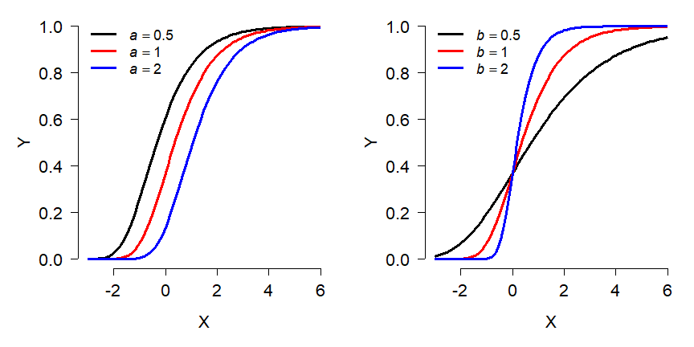

**Gompertz model form 2 (more common)**

$$f\left(x\right)={ae}^{-e^{b-ct}}$$

- *a*: Asymptote (maximum value)
- *b*: Displacement along *x*-axis (shifts left or right)
- *c*: Growth rate (similar to *b* in form 1)

The figure below shows the effects of varying the parameters in the second form of the Gompertz model:

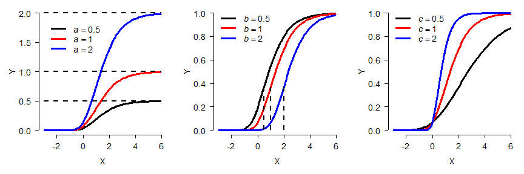

**von Betalanffy model**

Like the Gompertz curve, the von Bertalanffy growth curve describes size increasing and approaching an asymptote. The von Bertalanffy model is commonly written as:

$$f\left(x\right)=L_\infty\left(1-e^{-k\left(x-t_0\right)}\right)$$

- *$L_{\infty}$*: Asymptotic length as *x* approaches $\infty$
- *k*: Growth rate
- *$t_0$*: Theoretical time at which $f(x)=0$. I.e., displacement along *x*-axis. Should be negative.

The von Bertalanffy model is commonly used in fisheries to describe fish growth, but in principle it could be used for any situation where its parameters make sense. The same function is also sometimes called the **monomolecular curve**. Like the Gompertz curve, the von Bertalanffy model has several forms. The form given above is the most common. The figure below shows the effects of varying the parameters in the von Bertalanffy model:

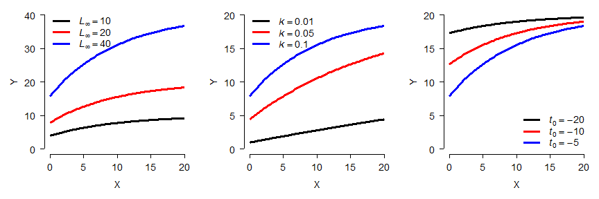

It should be noted that both the Gompertz and von Bertalanffy curves can also be used to model decreasing phenomena, but this is not commonly done.

## 2.1 Application to real data

Woodward et al. (2015) studied the life history dynamics of the Cretaceous hadrosaurid dinosaur *Maiasaura peeblesorum* (shown below). They used microscopic growth rings in the tibias of museum specimens to estimate age at death and the sizes of several bones to estimate total body length and mass. We will use their age and mass data to fit growth curves for this species.

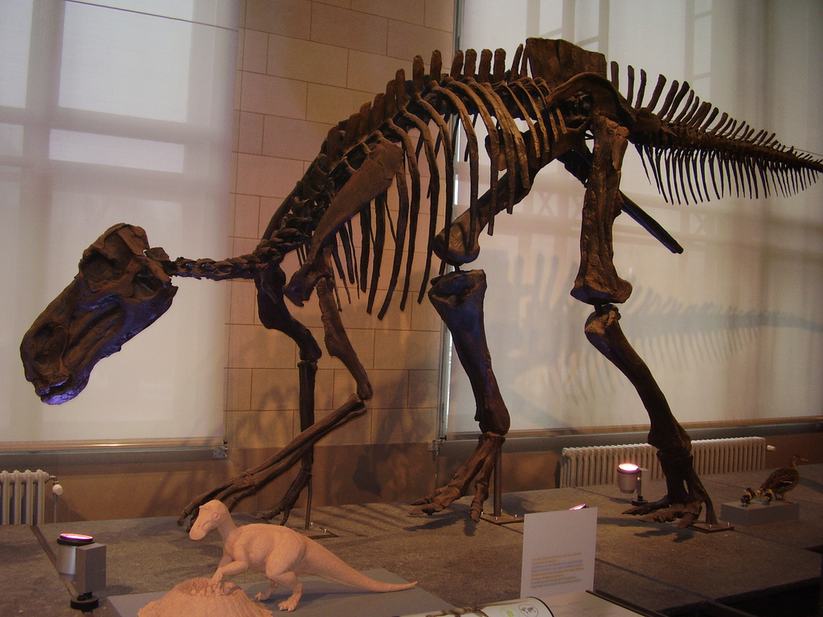

A mounted *Maiasaura* skeleton[^1].

The data are stored in the file woodward2015data.csv. Download the dataset and put it in your R home directory.

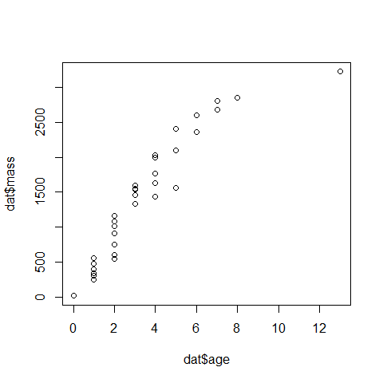

```r
in.name <- "woodward2015data.csv"
dat <- read.csv(in.name, header=TRUE)
plot(dat$age, dat$mass)
```

Use `nls()` to fit the two growth curves. There is a self-starting Gompertz model available, so we’ll use that. There is no self-start von Bertalanffy model, so we’ll have to guess at the parameters. Based on the plot above, we might guess that the asymptote $L_\infty$ is about 4000, and that $t_0$ is about -1. Using those rough estimates, we can rearrange the von Bertalanffy model and solve for the missing term *k* as:

$$\hat{k}=\frac{-\log{\left(1-\frac{f\left(x\right)}{L_\infty}\right)}}{x-t_0}$$

Or in R:

```r
est.k <- -1*(log(1-dat$mass/4000))/(dat$age- -1)
mean(est.k)
```

```
## [1] 0.09268849
```

The mean of the estimated *k* ($\hat{k}$, or “k-hat”) is about 0.09. So, we’ll use that for our starting guess. Now we can fit both the Gompertz and von Bertalanffy models:

```r
mod1 <- nls(mass~SSgompertz(age, A, B, C), data=dat)
mod2 <- nls(mass~Linf*(1-exp(-k*(age-t0))),
            data=dat,
            start=list(Linf=4e3, k=0.09, t0=-1))
summary(mod1)
```

```
##
## Formula: mass ~ SSgompertz(age, A, B, C)
##
## Parameters:
##    Estimate Std. Error t value Pr(>|t|)
## A 3.145e+03  1.718e+02   18.31  < 2e-16 ***
## B 3.076e+00  2.858e-01   10.76 3.64e-12 ***
## C 6.514e-01  3.081e-02   21.14  < 2e-16 ***
## ---
## Signif. codes:  0 '***' 0.001 '**' 0.01 '*' 0.05 '.' 0.1 ' ' 1
##
## Residual standard error: 208.4 on 32 degrees of freedom
##
## Number of iterations to convergence: 5
## Achieved convergence tolerance: 1.862e-06
```

```r
summary(mod2)
```

```
##
## Formula: mass ~ Linf * (1 - exp(-k * (age - t0)))
##
## Parameters:
##       Estimate Std. Error t value Pr(>|t|)
## Linf 3.966e+03  3.902e+02  10.165 1.52e-11 ***
## k    1.572e-01  2.656e-02   5.917 1.38e-06 ***
## t0   2.315e-01  1.288e-01   1.797   0.0817 .
## ---
## Signif. codes:  0 '***' 0.001 '**' 0.01 '*' 0.05 '.' 0.1 ' ' 1
##
## Residual standard error: 212.7 on 32 degrees of freedom
##
## Number of iterations to convergence: 7
## Achieved convergence tolerance: 1.781e-06
```

Both models were able to fit all of their parameters, although the $t_0$ term in the von Bertalanffy model was nonsignificant (i.e., not different from 0). This might indicate that we should go with the Gompertz model. The pseudo-*R*<sup>2</sup> values are similar and don’t strongly suggest choosing one model over another:

```r
pseudoR2 <- function(mod, Y){
    ss.tot <- sum((fitted(mod)-mean(Y))^2)
    ss.res <- sum(residuals(mod)^2)
    1-(ss.res/ss.tot)
}
pseudoR2(mod1, dat$mass)
```

```
## [1] 0.946444
```

```r
# [1] 0.946444
pseudoR2(mod2, dat$mass)
```

```
## [1] 0.9459103
```

```r
# [1] 0.9459103
```

The AICs of the models suggest that the Gompertz model is slightly better, but not significantly so. The difference in AIC is <2, suggesting that the models are equivalent in their support. This means that we would be justified choosing either one, or not choosing and presenting both.

```r
AIC(mod1, mod2)
```

```
##      df      AIC
## mod1  4 477.9660
## mod2  4 479.3922
```

```r
#      df      AIC
# mod1  4 477.9660
# mod2  4 479.3922
AIC(mod2) - AIC(mod1)
```

```
## [1] 1.426267
```

Another way to determine which model fits better is to compare their ability to predict out-of-sample data. That is, data that were not used to fit the model. The most common strategy for this is called “cross-validation”. There are many kinds of cross-validation. What they all have in common is that the model is fit to some of the data, and then its predictive accuracy is checked using the held-out data. One popular strategy is *k*-fold cross-validation, the data are divided into *k* subsets, or “folds”. Then, the model is fit *k* times: each time to all of the data except those in one fold. The predictive accuracy of these models is then calculated for the data in the fold that was left out. The better the model is at predicting out-of-sample data, the smaller the average error should be.

Let’s try another method called “leave-one-out” cross-validation. In this strategy, the model is fit to all observations except 1 at a time. Then, the root mean squared error (RMSE) is calculated for both models.

```r
N <- nrow(dat)
err1 <- numeric(N)
err2 <- err1

for(i in 1:N){
    mod1i <- nls(mass~SSgompertz(age, A, B, C), data=dat[-i,])
    mod2i <- nls(mass~Linf*(1-exp(-k*(age-t0))),
        data=dat[-i,],
        start=list(Linf=4e3, k=0.09, t0=-1))
    px <- data.frame(age=dat$age[i])
    err1[i] <- predict(mod1i,
        newdata=data.frame(px)) - dat$age[i]
    err2[i] <- predict(mod2i,
        newdata=data.frame(px)) - dat$age[i]
}
sqrt(mean(err1^2))
```

```
## [1] 1599.034
```

```r
sqrt(mean(err2^2))
```

```
## [1] 1634.066
```

Again, the Gompertz curve looks slightly better than the von Bertalanffy, but not by much. For our example let’s go ahead and plot both models.

```r
library(propagate)
px <- seq(min(dat$age), max(dat$age), length=25)
pred <- predictNLS(mod1,
                   newdata=data.frame(age=px),
                   interval="confidence")
pred <- pred$summary

mn1 <- pred$Sim.Mean
lo1 <- pred$'Sim.2.5%'
up1 <- pred$'Sim.97.5%'

pred2 <- predictNLS(mod2,
                   newdata=data.frame(age=px),
                   interval="confidence")
pred2 <- pred2$summary

mn2 <- pred2$Sim.Mean
lo2 <- pred2$'Sim.2.5%'
up2 <- pred2$'Sim.97.5%'
```

Now make the plot:

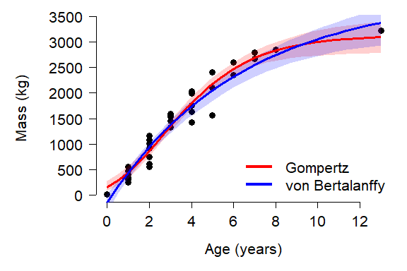

```r
par(mfrow=c(1,1), mar=c(5.1, 7.1, 1.1, 1.1),
    las=1, lend=1, bty="n",
    cex.axis=1.3, cex.lab=1.3)
# make the plot
plot(dat$age, dat$mass,
     pch=16, cex=1.2,
     xlab="Age (years)",
     ylab="", ylim=c(0,3400))
title(ylab="Mass (kg)", line=5)
polygon(x=c(px, rev(px)), y=c(lo1, rev(up1)),
    border=NA, col="#FF000030")
polygon(x=c(px, rev(px)), y=c(lo2, rev(up2)),
    border=NA, col="#0000FF30")
points(px, mn1, type="l", lwd=3, col="red")
points(px, mn2, type="l", lwd=3, col="blue")
legend("bottomright",
    legend=c("Gompertz", "von Bertalanffy"),
    lwd=4, col=c("red", "blue"),
    bty="n", cex=1.3)
```

It might be worth asking how fast the animals grew, and how that growth rate changed over the course of their lives. Technically, the growth rate would be the first derivative of the fitted function. However, getting a first derivative might be difficult or impossible for many NLS models. Instead, we can calculate the values empirically. Over a period of 12 years (the domain of our fitted function), daily time steps offer a reasonable approximation of the instantaneous rate of change (daily time steps are more biologically interpretable than a literally instantaneous rate, as well).

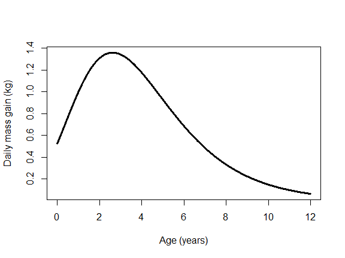

```r
# daily x values as fractional years
xday <- 0:(12*365.25) # Julian year length
xday <- xday / 365.25

# predicted daily mass
yday <- predict(mod1, newdata=data.frame(age=xday))

ydiff <- diff(yday)
xdiff <- 1:length(ydiff)/365.25

plot(xdiff, ydiff, type="l", lwd=3,
     xlab="Age (years)",
     ylab="Daily mass gain (kg)")
```

[**Go back to main page**](https://greenquanteco.github.io/index.html)

# 3 References

Bolker, B. M. 2008. Ecological models and data in R. Princeton University Press, Princeton, New Jersey, USA.

Woodward, H. N., E. A. F. Fowler, J. O. Farlow, and J. R. Horner. 2015. [*Maiasaura*, a model organism for extinct vertebrate population biology: A large sample statistical assessment of growth dynamics and survivorship](https://doi.org/10.1017/pab.2015.19). Paleobiology 41:503–527.

# 4 Legal notice

This site is for educational purposes only. This work and its content is released under the [Creative Commons Attribution-ShareAlike 4.0](https://creativecommons.org/licenses/by-sa/4.0/) license. Inclusion of third-party data falls under guidelines of fair use as defined in [section 107 of the US Copyright Act of 1976](https://www.law.cornell.edu/uscode/text/17/107).

[^1]: Photo: V. Socha. [Wikimedia](https://upload.wikimedia.org/wikipedia/commons/1/16/Maiasaura_skeleton.jpg) (accessed 2021-09-24)